# Belief_propogation_trees

```python
from IPython.display import Image
```

- $P(x_1,\ldots,x_n) = \prod_{i} p(x_i|pa(x_i))$

Query

- $P(x|e)$ where $e = \{X_i = x_i, X_j = x_j \}$

# Algorithm for polytree

- Polytree - singularly connected network
- Goal compute $P(x|e)$
- An arbitrary node $X$ divides the evidence into that connected to its causes $e_{X}^{+}$ and those connected to its effects $e_{X}^{-}$.
- Similarly a link $XY$ divides $e$ into the evidence above and below the link $e^{+}_{XY}$ and $e^{-}_{XY}$.

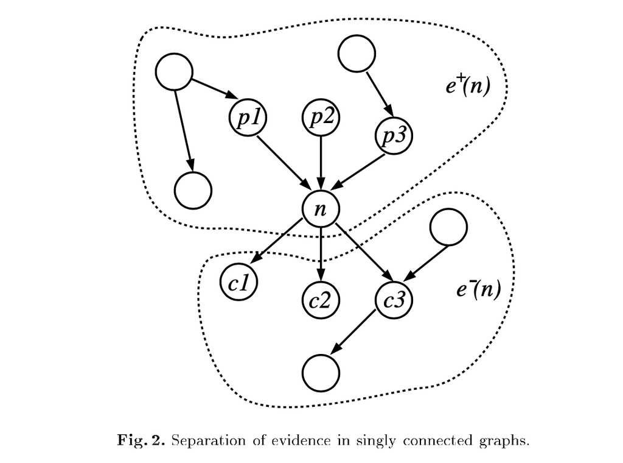

```python
Image("figs/polytree.png")
```

- We create the following definitions
1. $\pi(x) = P(x,e_{x}^{+})$
2. $\lambda(x) = P(e_{x}^{-}|x)$
3. $\pi_{X}(u_i) = P(u_i,e^{+}_{U_iX})$
4. $\lambda_{Y_j}(x) = P(e^{-}_{XY_j}|x)$

## The calculation

- $$P(x|e) = \frac{p(x,e)}{p(e)}$$
- Now $p(x,e) = p(x,e^{+}_X,e^{-}_X) = p(x,e^{+}_X)p(e^{-}_{X}|x,e^{+}_X)$

## Using d-seperation for singly connected networks

1. Two children $Y_i, Y_j$ of a node $X$ are independent given the value of their parent. $$P(Y_i|X) = P(Y_i|X,Y_j) $$
2. Aa parent $U_i$ and a child $Y_j$ of a node $X$ are independent given the value of $X$

$$P(U_i|X) = P(U_i|X,Y_j)$$

1. Two parents of a node $X$, which in a polytree are always a priori independent, in general become correlated by the instantiation of $X$

# Updating the calculation

- Using the d-seperation rule 2 we know that $P(e_{X}^{-}|x,e_{X}^{+}) = P(e_{X}^{-}|x)$ and so we can write

$p(x,e) = p(e^{+}_X,x)p(e^{-}_{X}|x)$ and thus

$$P(x|e) = \frac{p(e^{+}_X,x)p(e^{-}_{X}|x)}{p(e)} = \alpha \pi(x) \lambda(x)$$

where $\alpha=(p(e))^{-1}, \pi(x) = p(e^{+}_X,x)$ and $\lambda(x) = p(e^{-}_{X}|x)$

# Recursive structure: Parents

$\pi(x) = P(x,e_{X}^{+}) = \sum_{u \in U_1, \ldots, u \in U_k}P(x,e_{X}^{+},U_1,\ldots,U_k)$

Now $$P(x,e_{X}^{+},U_1,\ldots,U_k) = p(x|e_{X}^{+},U_1,\ldots,U_k)P(U_1,\ldots,U_k,e_{U_1 X}^{+},e_{U_2 X}^{+},\ldots,e_{U_k X}^{+})$$

since we can break the evidence above the node x into the evidence above each of the links $XU_i$.

Now using the d-seperation rule 2. we know that $p(x|e_{X}^{+},U_1,\ldots,U_k) = p(x|U_1,\ldots,U_k)$ similarly we know using d-seperation rule 3. that $P(U_1,\ldots,U_k,e_{U_1 X}^{+},e_{U_2 X}^{+},\ldots,e_{U_k X}^{+}) = \prod_{i=1}^{k} P(U_i,e_{U_i X}^{+})$

Hence $$P(x,e_{X}^{+}) \sum_{u_1,\ldots,u_n} P(x|u_1,\ldots,u_n) \prod_{i=1}^n \pi_{X}(u_i). $$ Where $\pi_{X}(u_i) = P(U_i,e_{U_i X}^{+})$

# Recursive structure: Children

- $\lambda(x) = P(e_{X}^{-}|x)$

$e_{X}^{-} = e^{-}_{XY_1} \cap e^{-}_{XY_2} \cap \ldots \cap e^{-}_{XY_m}$

Hence $P(e_{X}^{-}|x) = P(e^{-}_{XY_1} \cap e^{-}_{XY_2} \cap \ldots \cap e^{-}_{XY_m}|x)$

using d-seperation rule 1

$P(e^{-}_{XY_1} \cap e^{-}_{XY_2} \cap \ldots \cap e^{-}_{XY_m}|x) = \prod_{i=1}^{m} P(e^{-}_{XY_i}|x)$

Hence $\lambda(x) = \prod_{i=1}^m \lambda_{Y_{j}}(x)$

- Now what we want is a way to compute $\lambda_{Y_{j}}(x)$

### recurrance relation 9

$$p(x,e) = p(x,e_{X}^{+},e_{X}^{-}) = p(x,e_{XY_j}^{+},e_{XY_j}^{-})$$

$p(x,e_{X}^{+})p(e_{X}^{-}|x) = p(x,e_{XY_j}^{+})p(e_{XY_j}^{-}|x)$

$$\pi(x) \lambda(x) = \pi_{Y_j}(x)\lambda_{Y_j}(x)$$

hence

$$\pi_{Y_j}(x) = \pi(x) \frac{\lambda(x)}{\lambda_{Y_j}(x)} $$

### recurrance relation 10

$\lambda_{y_j}(x) = P(e_{xy_j}^-|x)$ includes the evidence about $y$'s other parents $v_1,\ldots,v_p$ and their evidence $e_{v_1y_j}^{+},\ldots,e_{v_py_j}^{+}$ because it splits the graph either side of $x$ and $y_j$. The evidence $e_{v_1y_j}^{+},\ldots,e_{v_py_j}^{+}$ lies on the side of things connected to $y_j$.

Hence $$e_{xy_j}^- = e_{v_1y_j}^{+} \cap \ldots \cap e_{v_py_j}^{+} \cap e^{-}_{y_j}$$

and thus

$$\lambda_{y_j}(x) = P(e_{v_1y_j}^{+} \cap \ldots \cap e_{v_py_j}^{+} \cap e^{-}_{y_j}|x) = \sum_{y_j}P(e_{v_1y_j}^{+} \cap \ldots \cap e_{v_py_j}^{+} \cap e^{-}_{y_j},y_j|x) = \sum_{y_j} P(e^{-}_{y_j}|e_{v_1y_j}^{+} \cap \ldots \cap e_{v_py_j}^{+} \cap y_j)P(e_{v_1y_j}^{+} \cap \ldots \cap e_{v_py_j}^{+} \cap y_j)$$

since given $$e_{y_j}^{-} \perp e_{v_1y_j}^{+},\ldots,e_{v_py_j}^{+}|y_j$$ by d-seperation

we have $$\lambda_{y_j}(x) = \sum_{y_j} P(e^{-}_{y_j}|y_j)P(e_{v_1y_j}^{+} \cap \ldots \cap e_{v_py_j}^{+} \cap y_j) = \sum_{y_j}\lambda(y_j)P(e_{v_1y_j}^{+} \cap \ldots \cap e_{v_py_j}^{+} \cap y_j)$$

Now we can write

$$P(e_{v_1y_j}^{+}, \ldots ,e_{v_py_j}^{+},y_j) = \sum_{v_1,\ldots,v_p} P(e_{v_1y_j}^{+},\ldots,e_{v_py_j}^{+}, v_1,\ldots,v_p,y_j) = \sum_{v_1,\ldots,v_p} P(y_j|e_{v_1y_j}^{+},\ldots,e_{v_py_j}^{+}, v_1,\ldots,v_p)P(e_{v_1y_j}^{+},\ldots,e_{v_py_j}^{+}, v_1,\ldots,v_p)$$

since we have marginal independence between the $e_{v_1y_j}^{+},\ldots,e_{v_py_j}^{+}, v_1,\ldots,v_p$ we have

$$P(e_{v_1y_j}^{+},\ldots,e_{v_py_j}^{+}, v_1,\ldots,v_p) = \prod_{i=1}^{p} P(v_{i},e_{V_iY_j}^{+}) = \prod_{i=1}^{p} \pi_{Y_j}(v_k) $$

Finally we have that

$$\lambda_{Y_j}(x) = \sum_{y_j} \left(\lambda(y_j) \sum_{v_1,\ldots,v_p} P(y_j|x,v_1,\ldots,v_p) \prod_{k=1}^p \pi_{Y_j}(v_k)\right).$$